# FA_exmaple

요인2: 디자인 관련 불편 (디자인안세련, 디자인안다양)

요인3: 가슴부위 관련 불편 (가슴못모음, 가슴못받침, 가슴못고정)

요인4: 옷의 질 관련 불편 (거친촉감, 원단신축성없음, 답답함, 땀흡수안됨)

요인5: 컵 및 치수 안맞음 관련 불편 (컵작음, 치수안맞음, 컵조임)

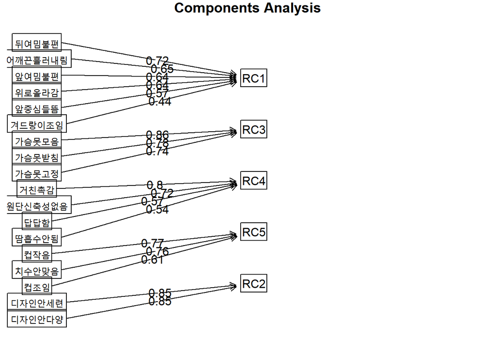

```r
# diagram
fa.diagram(Mfapcvmx, simple = FALSE, cut=0.43, digits = 2)
```

=> 앞에서 cut을 0.43으로 지정해서 겹치는 요인이 없다.

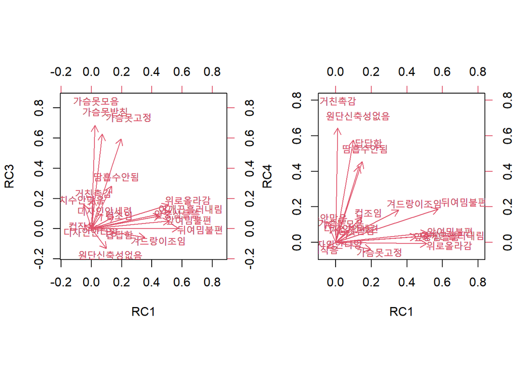

```r
# biplot
par(mfrow=c(1,2))
biplot(Mfapcvmx$loadings[,c(1,2)], Mfapcvmx$loadings[,c(1,2)])
biplot(Mfapcvmx$loadings[,c(1,3)], Mfapcvmx$loadings[,c(1,3)])
```

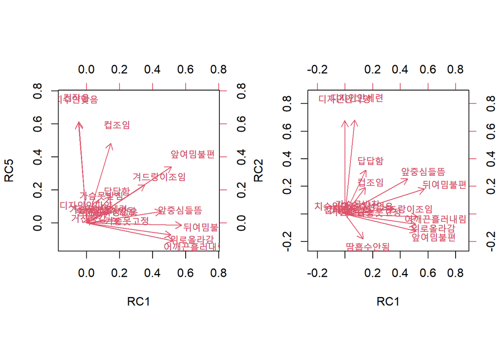

```r
biplot(Mfapcvmx$loadings[,c(1,4)], Mfapcvmx$loadings[,c(1,4)])
biplot(Mfapcvmx$loadings[,c(1,5)], Mfapcvmx$loadings[,c(1,5)])
```

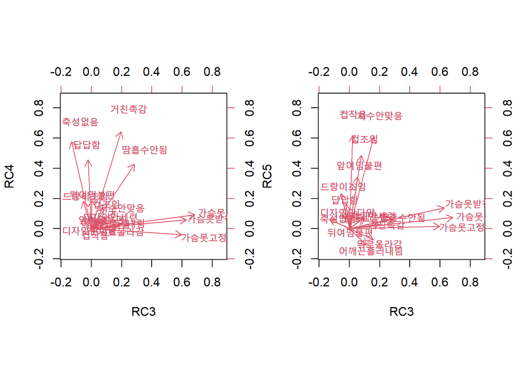

```r
biplot(Mfapcvmx$loadings[,c(2,3)], Mfapcvmx$loadings[,c(2,3)])
biplot(Mfapcvmx$loadings[,c(2,4)], Mfapcvmx$loadings[,c(2,4)])
```

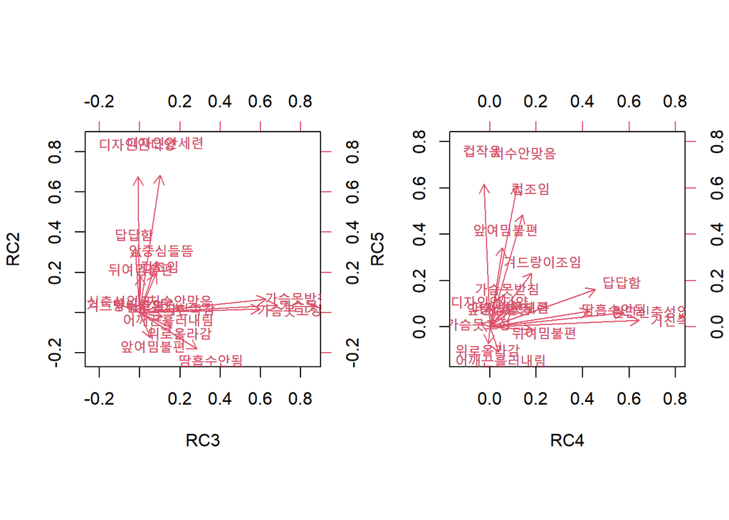

```r
biplot(Mfapcvmx$loadings[,c(2,5)], Mfapcvmx$loadings[,c(2,5)])
biplot(Mfapcvmx$loadings[,c(3,4)], Mfapcvmx$loadings[,c(3,4)])
```

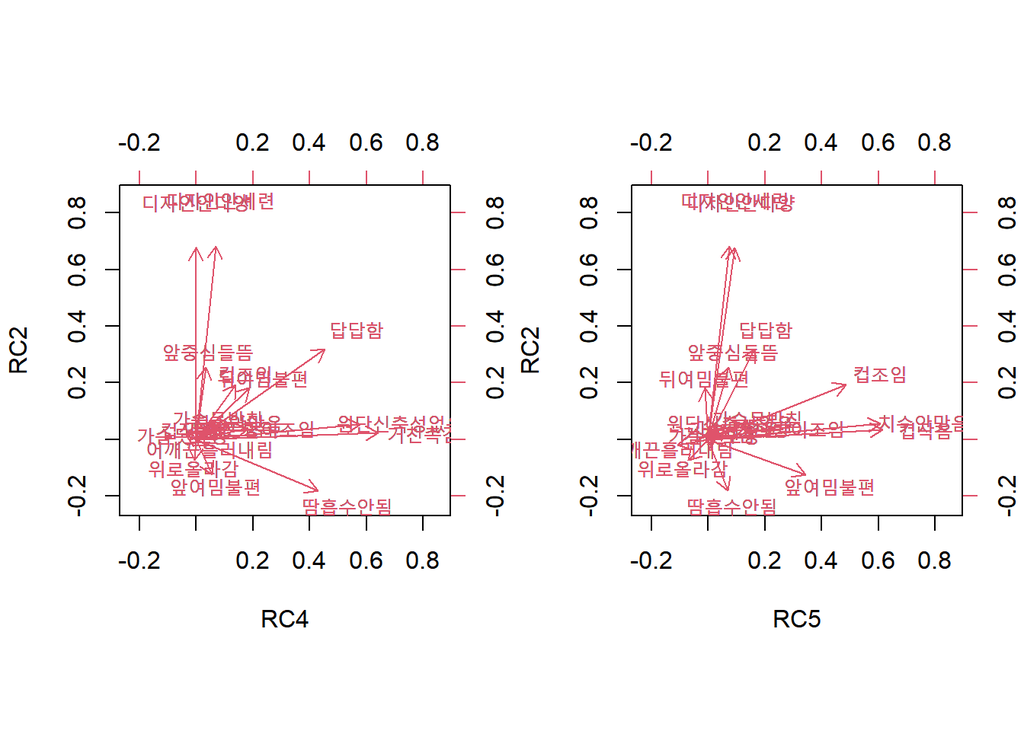

```r
biplot(Mfapcvmx$loadings[,c(3,5)], Mfapcvmx$loadings[,c(3,5)])
biplot(Mfapcvmx$loadings[,c(4,5)], Mfapcvmx$loadings[,c(4,5)])
```

```r
par(mfrow=c(1,1))
```

=> 전반적으로 축이 붙어서 한쪽으로 몰린 상태 (90도와 유사)한 상태이다. 따라서 회전은 적절하다 할 수 있다.